# Bayesian Analysis

Vanila Linear Regression : Using R

|  | income | infant | region | oil |
| --- | --- | --- | --- | --- |
| Australia | 3426 | 26.7 | Asia | no |
| Austria | 3350 | 23.7 | Europe | no |
| Belgium | 3346 | 17.0 | Europe | no |
| Canada | 4751 | 16.8 | Americas | no |
| Denmark | 5029 | 13.5 | Europe | no |
| Finland | 3312 | 10.1 | Europe | no |

```r
str(Leinhardt)
```

```
'data.frame':   105 obs. of  4 variables:
 $ income: int  3426 3350 3346 4751 5029 3312 3403 5040 2009 2298 ...
 $ infant: num  26.7 23.7 17 16.8 13.5 10.1 12.9 20.4 17.8 25.7 ...
 $ region: Factor w/ 4 levels "Africa","Americas",..: 3 4 4 2 4 4 4 4 4 4 ...
 $ oil   : Factor w/ 2 levels "no","yes": 1 1 1 1 1 1 1 1 1 1 ...
```

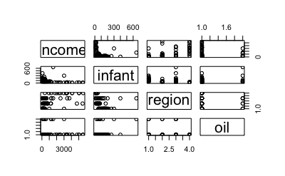

It can be seen from the pairs plot that the relationship between continuous variables (income and infant) is not linear. For variables infant and income the distribution seems heavily right skewed

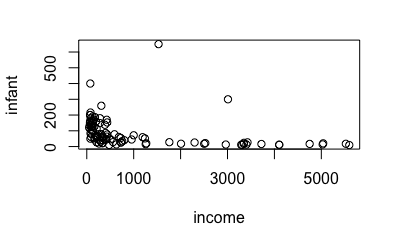

Just to confirm if the plot are histogram

```r
par(1,2)
```

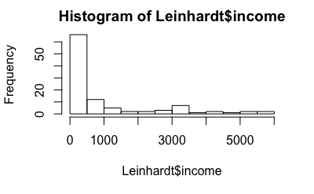

```r
hist(Leinhardt$income)
```

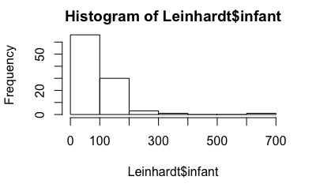

```r
hist(Leinhardt$infant)
```

Lets plot the variable in the log scale and see if the relationship becomes linear. Yes they seem linear now.

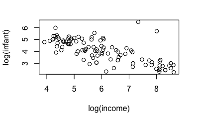

MODELING : With vanila Linear Regression on the linear scale using only the income as variable. We can see that the R-squred is barely doing good. It makes sense becasue evan though the data seemed a good fit, it is visible that not all the variability is explained by the variable income. However, the variable is significant

```r
dat = na.omit(Leinhardt)
dat$log_income = log(dat$income)
dat$log_infant = log(dat$infant)
lmod = lm(log_infant ~ log_income, data=dat)
summary(lmod)
```

```
Call:
lm(formula = log_infant ~ log_income, data = dat)

Residuals:
     Min       1Q   Median       3Q      Max
-1.66694 -0.42779 -0.02649  0.30441  3.08415

Coefficients:
            Estimate Std. Error t value Pr(>|t|)
(Intercept)  7.14582    0.31654  22.575   <2e-16 ***
log_income  -0.51179    0.05122  -9.992   <2e-16 ***
---
Signif. codes:  0 ‘***’ 0.001 ‘**’ 0.01 ‘*’ 0.05 ‘.’ 0.1 ‘ ’ 1

Residual standard error: 0.6867 on 99 degrees of freedom
Multiple R-squared:  0.5021,    Adjusted R-squared:  0.4971
F-statistic: 99.84 on 1 and 99 DF,  p-value: < 2.2e-16
```

# RECREATING THE MODEL WITH JAGGS -> THE BAYESIAN INTERPRETATION

```r
library(rjags)
```

SETTING UP THE MODEL- TO RUN

```r
set.seed(75)
# Feeding inputs to the Jaggs Model
data1_jags = list(y=dat$log_infant, n=nrow(dat), log_income=dat$log_income, is_oil=as.numeric(dat$oil=="yes"))
# Fetch the parameters that we would want to monitor
params1 = c("b", "sig")
# Provide the model with the initial variables
inits1 = function(){
  # We sample two values from the normal distribution for each b1, b2 and b3.
  # Here we use the normal distribution from R package hence we use sd instead of 1/sd
  inits = list("b"=rnorm(3, mean = 0.0, sd=100),
               "prec"=rgamma(1, shape = 1.0, rate = 1.0)) # actually a exponential distribution


}
```

```r
mod1 = jags.model(textConnection(mod1_string), data=data1_jags, inits = inits1, n.chains = 3)
# Give the model a burn-in period to atleast reach settle in its parameter search space
update(mod1, 1000)
```

[output not shown]

```r
# Create Posterior simulations
mod1_sim = coda.samples(model=mod1, variable.names=params1, n.iter=5e3)
```

[output not shown]

```r
# Cobine the 3 markov chain simulations
mod1_csim = do.call(rbind, mod1_sim)
```

### Convergence Diagnostic :

#### 1. Trace Plots: The trace plots looks fine, we can see that the Markov chain reaches a stationary point. The three color indicates the three Markov chains we have run.

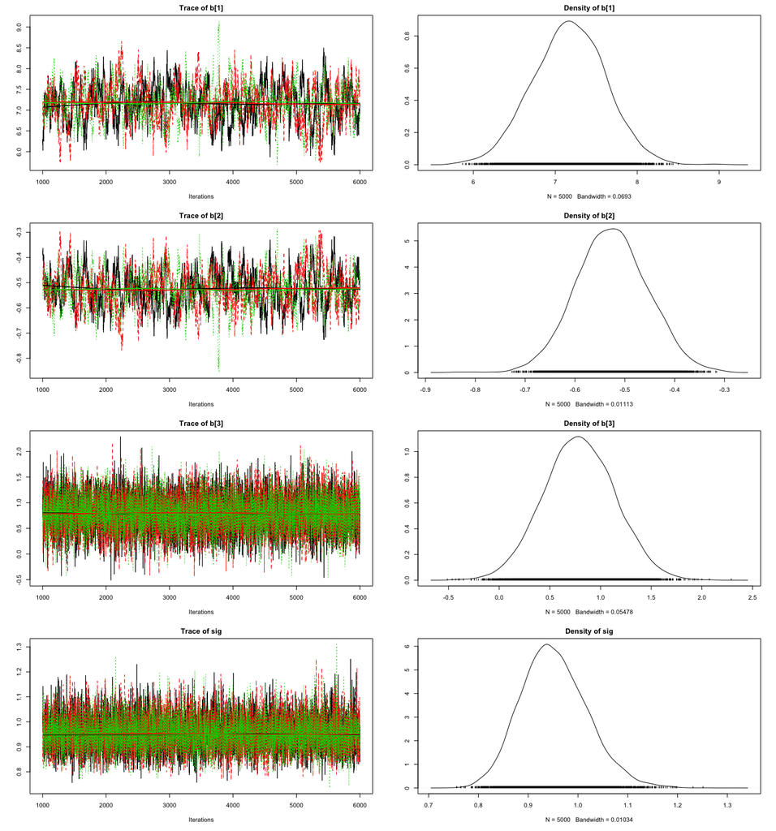

#### 2. Gelmann and Rubin Diagnostic: The diagnoistic compares the variance in each chain to the variance between different markov chains. Any smaller value close to 1 indicate stationary state and convergence.

```r
gelman.diag(mod1_sim)
```

```
Potential scale reduction factors:

     Point est. Upper C.I.
b[1]          1       1.01
b[2]          1       1.01
b[3]          1       1.00
sig           1       1.00

Multivariate psrf

1
```

#### 3. Autocorrelation: The autocorrelation measures the lag between the samplings for a markov chain. If the autocorrelation is high say until 100 lag, that means that if we sample every 100th value (1th, 100th, 200th, 300th …) from the markov chain then using only these samples to estimate the parameter mean and variance would make sense.

A good model: A good model would have low autocorrelation in just few lags say 5 or 10. Again it depends from domain to domain.

```r
autocorr.diag(mod1_sim)
```

```
             b[1]       b[2]        b[3]          sig
Lag 0  1.00000000 1.00000000 1.000000000  1.000000000
Lag 1  0.95400951 0.95478299 0.085327750  0.019576965
Lag 5  0.78715654 0.78736806 0.003381341  0.002236463
Lag 10 0.61783707 0.61856412 0.008956083 -0.010100597
Lag 50 0.07726648 0.07565098 0.007763999  0.002790243
```

```r
mod1_sim[1][:,2]
```

[output not shown]

#### 4. Effective Size:

Since we had high autocorrelation for b[1] and b[2], it is good to check the effective size. Effective size stores the number of samples that were actually effective among all the samples.

```r
effectiveSize(mod1_sim)
```

```
      b[1]       b[2]       b[3]        sig
  356.4389   355.2122 12640.9513 15024.1660
```

#### 5. POSTERIOR SUMMARY: The posterior summary looks very similar to the vanilla linear regression summary

LM model: b1: 7.145, b2: -0.511, sig (standard error): 0.6867

b1 and b2 estimate are quite close, but the sig varies a lot. This is because of our prior belief that prior_sample_size = 5 prior_guess_for_variance = 10

If we are not very sure of prior, we would lower the value and woult therefore get a small sig.

```r
summary(mod1_sim)
```

```
Iterations = 1001:6000
Thinning interval = 1
Number of chains = 3
Sample size per chain = 5000

1. Empirical mean and standard deviation for each variable,
   plus standard error of the mean:

        Mean      SD  Naive SE Time-series SE
b[1]  7.1687 0.44733 0.0036524      0.0237837
b[2] -0.5259 0.07248 0.0005918      0.0038758
b[3]  0.7910 0.35364 0.0028874      0.0031452
sig   0.9524 0.06678 0.0005452      0.0005454

2. Quantiles for each variable:

        2.5%     25%     50%     75%   97.5%
b[1]  6.2936  6.8705  7.1763  7.4739  8.0334
b[2] -0.6668 -0.5742 -0.5267 -0.4779 -0.3827
b[3]  0.1036  0.5531  0.7884  1.0294  1.4856
sig   0.8327  0.9060  0.9481  0.9957  1.0938
```

```r
summary(lmod)
```

```
Call:
lm(formula = log_infant ~ log_income, data = dat)

Residuals:
     Min       1Q   Median       3Q      Max
-1.66694 -0.42779 -0.02649  0.30441  3.08415

Coefficients:
            Estimate Std. Error t value Pr(>|t|)
(Intercept)  7.14582    0.31654  22.575   <2e-16 ***
log_income  -0.51179    0.05122  -9.992   <2e-16 ***
---
Signif. codes:  0 ‘***’ 0.001 ‘**’ 0.01 ‘*’ 0.05 ‘.’ 0.1 ‘ ’ 1

Residual standard error: 0.6867 on 99 degrees of freedom
Multiple R-squared:  0.5021,    Adjusted R-squared:  0.4971
F-statistic: 99.84 on 1 and 99 DF,  p-value: < 2.2e-16
```

#### 6. Residual Summary:

Understanding residual is a very important diagnostic becasue they can show any sign of violation in our assumption. In particular we are looking for below signs. 1. the model is not linear, 2. the observation are not independent from each other, 3. the model is not normally distributed

—-> Framing the problem: From the Bayesian estimation we got a estimated mean for b[0], b[1] and sig Here we just construct them to make dot products and predictions on the same sample data using the parameters estimated from Bayesian model.

```r
X = cbind(rep(1.0, data1_jags$n), data1_jags$log_income, data1_jags$is_oil)
print ('X matrix')
```

```
[1] "X matrix"
```

```r
print (head(X))
```

```
     [,1]     [,2] [,3]
[1,]    1 8.139149    0
[2,]    1 8.116716    0
[3,]    1 8.115521    0
[4,]    1 8.466110    0
[5,]    1 8.522976    0
[6,]    1 8.105308    0
```

```r
pm_params1 = colMeans(mod1_csim)
print('Parameter Mean')
```

```
[1] "Parameter Mean"
```

```r
print(pm_params1)
```

```
      b[1]       b[2]       b[3]        sig
 7.1686923 -0.5258532  0.7910019  0.9524406
```

```r
y_hat1 = X %*% pm_params1[1:3]
print ('Predicted values')
```

```
[1] "Predicted values"
```

```r
print (head(y_hat1))
```

```
         [,1]
[1,] 2.888695
[2,] 2.900491
[3,] 2.901119
[4,] 2.716761
[5,] 2.686857
[6,] 2.906490
```

```r
# Convert y_hat into a vectors
y_hat1 = drop(y_hat1)
# Get the residuals
resid1 = data1_jaggs$y - y_hat1
```

—-> Residual plot: Residual plot is a good check for linearity. Any curve pattern in residual plot would indicate polynomial fit to data. NOTE: All the statistics are measured on the LOG scale to our bayesian fit. Hence teh data was never linear. The residual plot looks much better, random, there seems to be no pattern

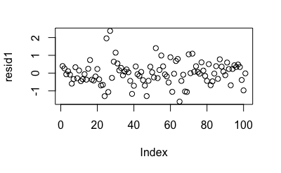

—-> Prediction Vs Residual: Looks pretty good, no trends. 1. The residual mean seems to be appx 0, hence linearity verified 2. The residual variance however tends to increase as we go from small predicted values to large predicted values 3. We see two outliers, not strong but atleast 3 sd away from the mean of the residual plot

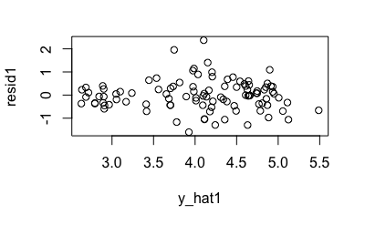

—-> QQ-plot: The qq-plot check our assumtion of normality. This plot actually compares a normal distribution to the residual distribution. If the residual distribution is right or left skewed then teh normal distribution would not be compliant and we would observe curve in the QQ-plot.

1. The residuals are normal since the sampled quantiles lie in a straight line
2. We can even see two outlier

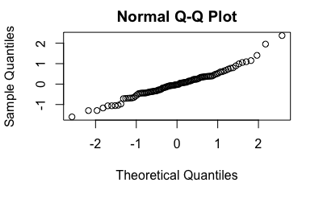

—-> Outliers: We repeatdly saw 2 outliers in the residual plot. Here we see which countries are they

1. As expected they are Saudi Arabia and Libya

```r
head(rownames(dat)[order(resid1, decreasing=TRUE)])
```

```
[1] "Saudi.Arabia" "Libya"        "Zambia"       "Brazil"       "Afganistan"   "Turkey"
```

## LETS GET RID OF THE OUTLIER:

THE Outlier’s ARE NAMED Saudi and Libya, which could possibly mean. We saw that the outliers were atleast 3 standard deviation away from the mean. So it would be wise to use some distribution that would have fatter tail. WHy not draw y’s from a t-distribution.

Hmm, this disn’t work as expected. But hey, even a t-distribution said that these points were outlier, this brings up the question. Are they really outliers, can we actually remove them.

```r
set.seed(75)

# Feeding inputs to the Jaggs Model
data2_jags = list(y=dat$log_infant, n=nrow(dat), log_income=dat$log_income, is_oil=as.numeric(dat$oil=="yes"))

# Fetch the parameters that we would want to monitor
params2 = c("b", "sig2")

# Provide the model with the initial variables
inits2 = function(){
  # We sample two values from the normal distribution for each b1, b2 and b3.
  # Here we use the normal distribution from R package hence we use sd instead of 1/sd
  inits = list("b"=rnorm(3, mean = 0.0, sd=100),
               "tau"=rgamma(1, shape = 1.0, rate = 1.0)) # actually a exponential distribution


}
```

```r
mod2 = jags.model(textConnection(mod2_string), data=data2_jags, inits = inits2, n.chains = 3)
```

[output not shown]

```r
# Give the model a burn-in period to atleast reach settle in its parameter search space
update(mod2, 1000)
```

[output not shown]

```r
# Create Posterior simulations
mod2_sim = coda.samples(model=mod2, variable.names=params2, n.iter=5e3)
```

[output not shown]

```r
# Cobine the 3 markov chain simulations
mod2_csim = do.call(rbind, mod2_sim)
```

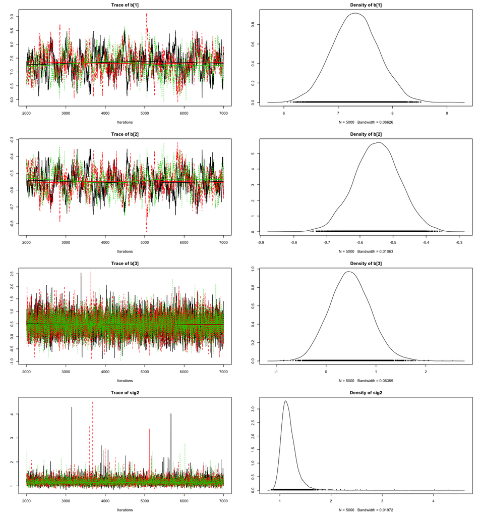

```r
X2 = cbind(rep(1.0, data2_jags$n), data2_jags$log_income, data2_jags$is_oil)
print ('X2 matrix')
```

```
[1] "X2 matrix"
```

```r
print (head(X2))
```

```
     [,1]     [,2] [,3]
[1,]    1 8.139149    0
[2,]    1 8.116716    0
[3,]    1 8.115521    0
[4,]    1 8.466110    0
[5,]    1 8.522976    0
[6,]    1 8.105308    0
```

```r
pm_params2 = colMeans(mod2_csim)
print('Parameter Mean')
```

```
[1] "Parameter Mean"
```

```r
print(pm_params2)
```

```
      b[1]       b[2]       b[3]       sig2
 7.2549525 -0.5396964  0.4925538  1.1733215
```

```r
y_hat2 = X2 %*% pm_params2[1:3]
print ('Predicted values')
```

```
[1] "Predicted values"
```

```r
print (head(y_hat2))
```

```
         [,1]
[1,] 2.862283
[2,] 2.874391
[3,] 2.875035
[4,] 2.685823
[5,] 2.655133
[6,] 2.880547
```

```r
# Convert y_hat into a vectors
y_hat2 = drop(y_hat2)
# Get the residuals
resid2 = data1_jaggs$y - y_hat2
```

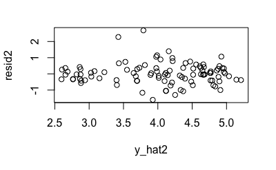

# MODEL EVALUATION:

```r
dic.sampled(lmod)
```

[output not shown]